# Reproducible Research: Peer Assessment 1

coursera.org - repdata-007  
Brendan Swiniarski - October 2014

## Data

I will be using the 'activity.csv' unzipped from the original zip file provided in the [git repository](https://github.com/rdpeng/RepData_PeerAssessment1) that we forked for this assignment, and made available from the hosted file [linked in the assignment's instructions](https://d396qusza40orc.cloudfront.net/repdata%2Fdata%2Factivity.zip).

This dataset contains self-reported activity in number of steps per 5-minute interval throughout each day, from October 1, 2012 through November 30, 2012.

This dataset follows the following scheme:

- **steps**: Number of steps, missing values coded as `NA`.
- **date**: The date on which the observation was reported in YYYY-MM-DD format.
- **interval**: Identifier for the 5-minute interval, starting at `0` and incrementing by `5` till it reaches `55`, then it rolls over to `100`, it goes all the way up to `2355` each day.
  - *NB*: This format is very confusing. think of it as format like **HH:MM**, but with leading zeros removed. We will be cleaning this up before we use it in time series charts, but even without preprocessing it into a `POSIXct` format it can be useful as an ordinal numbering system.

## Loading and preprocessing the data

#### Downloading the dataset

To begin with, we will need the dataset, available at the [link mentioned above](https://d396qusza40orc.cloudfront.net/repdata%2Fdata%2Factivity.zip).  
We need to be OS-conscious here, the internal methods for UNIX-based systems **do no support https**, so in that case we need to use the `rcurl` package.

```r
# This code chunk will download the zip file into the working directory.
if (.Platform$OS.type == 'unix') {
    download.file('https://d396qusza40orc.cloudfront.net/repdata%2Fdata%2Factivity.zip',
                  'repdata_data_activity.zip', method='curl')
} else {
    download.file('https://d396qusza40orc.cloudfront.net/repdata%2Fdata%2Factivity.zip',
                  'repdata_data_activity.zip')
}
```

Next we unzip the file and get our csv:

```r
unzip('repdata_data_activity.zip', 'activity.csv')
```

#### Reading and Preprocessing the dataset

There isn't much preprocessing to do at first. We will have some processing to do in later sections, however for now we can use the dataset as-is if we read it correctly. I will be using the `data.table` library, as it is faster and more memory efficient.

I am going to coerce `fread()` to read the steps as a `double` numeric value rather than as an `integer`, because it saves us from having to do it later when we look at fixing missing values, and does not affect any of our other usage throughout this process.

```r
library(data.table)
activity <- fread('activity.csv', colClasses=c('double', 'character', 'integer'))
```

From this function, we now have a `data.table`, let's see what it looks like. Notice we have **many** `NA`'s - we will be fixing that later on.

```r
activity
```

```
##        steps       date interval
##     1:    NA 2012-10-01        0
##     2:    NA 2012-10-01        5
##     3:    NA 2012-10-01       10
##     4:    NA 2012-10-01       15
##     5:    NA 2012-10-01       20
##    ---
## 17564:    NA 2012-11-30     2335
## 17565:    NA 2012-11-30     2340
## 17566:    NA 2012-11-30     2345
## 17567:    NA 2012-11-30     2350
## 17568:    NA 2012-11-30     2355
```

## What is mean total number of steps taken per day?

First, let's see what a plot of the total number of steps taken each day looks like. **NOTE**: I'm not including observations that have `NA` values for steps.

```r
sum.steps.by.day <- activity[!is.na(steps),sum(steps), by=date]
sum.steps.by.day[,date:=as.POSIXct(sum.steps.by.day$date)]
```

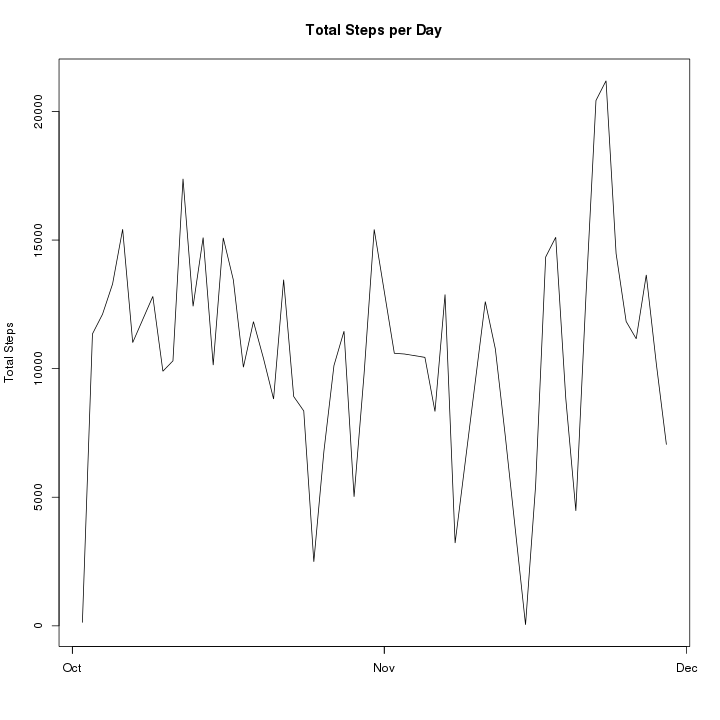

```r
plot(sum.steps.by.day$V1 ~ sum.steps.by.day$date,
     ylab='Total Steps', xlab='', type="l",
     main='Total Steps per Day')
```

Now, for statistics' sake, let's find the mean and median:

```r
mean(sum.steps.by.day$V1)
```

```
## [1] 10766
```

```r
median(sum.steps.by.day$V1)
```

```
## [1] 10765
```

Later, I'll be comparing these values to the same statistics after having “fixed” `NA` values in the dataset.

## What is the average daily activity pattern?

#### What else can this dataset tell us?

Let's look at the steps taken over the course of an average day, note that I am once again filtering out the intervals with `NA` observations:

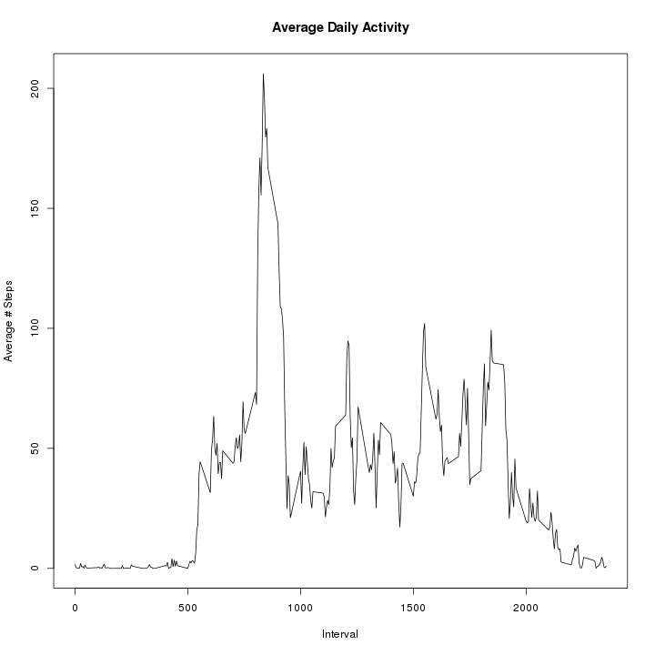

```r
average.day.by.interval <- activity[!is.na(steps),mean(steps), by=interval]
plot(average.day.by.interval$V1 ~ average.day.by.interval$interval, type='l',
     xlab='Interval', ylab='Average # Steps',
     main='Average Daily Activity')
```

So when is this dataset *most* active on average?

```r
average.day.by.interval[order(-V1)]
```

```
##      interval    V1
##   1:      835 206.2
##   2:      840 195.9
##   3:      850 183.4
##   4:      845 179.6
##   5:      830 177.3
##  ---
## 284:      350   0.0
## 285:      355   0.0
## 286:      415   0.0
## 287:      500   0.0
## 288:     2310   0.0
```

This individual is clearly a morning person: 8:35 AM is, on average, the most active interval, with the rest of that time period from 8:30 to 8:50 taking up the top 5 most active intervals on average.

## Imputing missing values

Now let's take a look at our dataset's missing values.

```r
na.values <- activity[,c(sum(is.na(steps)), sum(!is.na(steps)))]
na.values
```

```
## [1]  2304 15264
```

Here we can clearly see we have **2304** `NA` values and **15264** observations with usable data.

So how can we impute these values? The best approach is one that doesn't inherently skew our baseline statistics. What I'm going to do is use our data for the average of each interval, and replace `NA` values with that. At worst, this will skew our results very slightly towards a pre-existing central tendency.

```r
# First we'll give our average.day.by.interval table some better column names
setnames(average.day.by.interval, c('i', 's'))

# Next, we'll copy our data table into a new object
imputed.activity <- data.table(activity[,])

# Then, since we need to go through this by row, we'll add a column that is akin
# to row numbers in a data frame. We'll be removing this later.

# .N is a special integer variable in data.table objects that is the count of
# all rows returned in this 'by', since we have no 'by' it counts all rows in
# the data.table
imputed.activity[,r:=1:.N]

# Using 'by=r' to go through each row, we will substitue the averages for NA
# values in our data.table
imputed.activity[,steps:={
    if (is.na(steps)) {
        average.day.by.interval[i==interval,s]
    } else {
        steps
    }
}, by=r]
```

Now let's do some of the same plotting and calculations on our newly imputed data set and see if there are any major differences:

```r
imputed.sum.steps.by.day <- imputed.activity[,sum(steps), by=date]
imputed.sum.steps.by.day[,date:=as.POSIXct(imputed.sum.steps.by.day$date)]
```

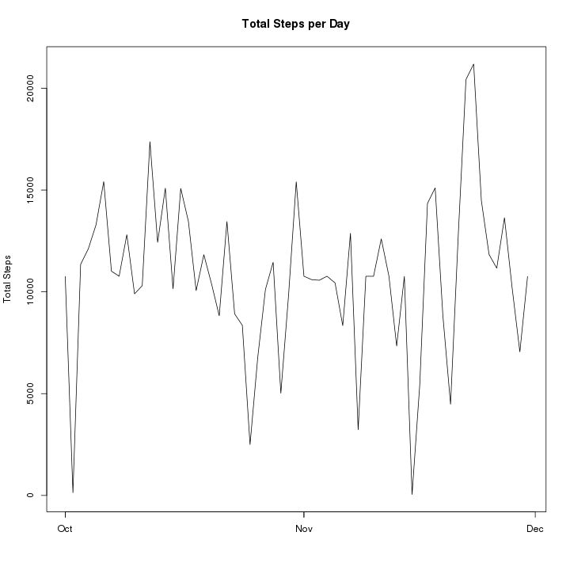

```r
plot(imputed.sum.steps.by.day$V1 ~ imputed.sum.steps.by.day$date,
     ylab='Total Steps', xlab='', type="l",
     main='Total Steps per Day')
```

```r
mean(imputed.sum.steps.by.day$V1)
```

```
## [1] 10766
```

```r
median(imputed.sum.steps.by.day$V1)
```

```
## [1] 10766
```

As for our figures, let's make it really clear how they've changed. Let's see what they look like overlayed on the same figure:

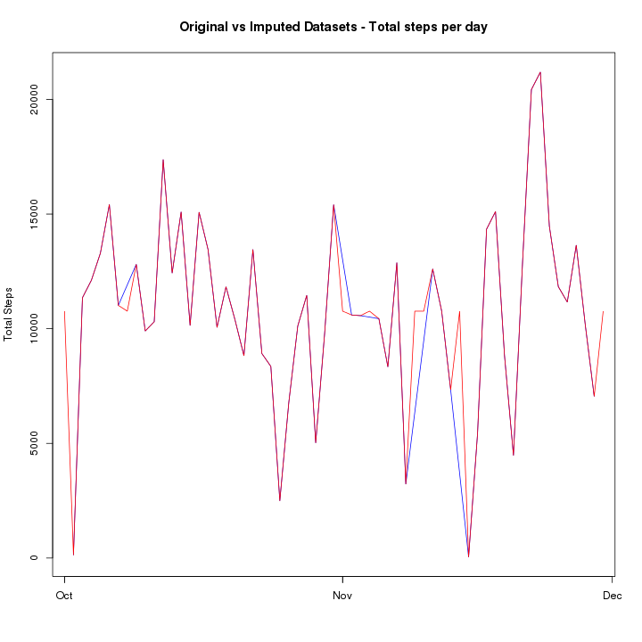

```r
#plot both sets of data on the same figure.
plot(sum.steps.by.day$V1 ~ sum.steps.by.day$date, type="n",
     main="Original vs Imputed Datasets - Total steps per day", ylab="Total Steps", xlab="")

lines(sum.steps.by.day$V1 ~ sum.steps.by.day$date, col="blue",
     type="l", main="Original Dataset", ylab="Total Steps", xlab="")

lines(imputed.sum.steps.by.day$V1 ~ imputed.sum.steps.by.day$date, col="red",
     type="l", main="Imputed Dataset", ylab="Total Steps", xlab="")
```

This doesn't show us much difference, so let's view the data another way using histograms to compare the original dataset to its imputed cousin:

```r
#Plot a histogram of our original dataset, then plot a density line
sum.hist <- hist(sum.steps.by.day$V1, breaks=length(sum.steps.by.day$V1))
# we are using this multiplier to overlay the density line on our
# frequency histogram, otherwise the density line is in the range of 1e-6
multiplier <- sum.hist$counts/sum.hist$density
sum.density <- density(sum.steps.by.day$V1)
sum.density$y <- sum.density$y * multiplier[1]

#Same process for our imputed dataset
imputed.sum.hist <- hist(imputed.sum.steps.by.day$V1,
                         breaks=length(imputed.sum.steps.by.day$V1))
imputed.multiplier <- imputed.sum.hist$counts/imputed.sum.hist$density
imputed.sum.density <- density(imputed.sum.steps.by.day$V1)
imputed.sum.density$y <- imputed.sum.density$y * imputed.multiplier[1]
```

Now let's see what our two histograms look like side-by-side:

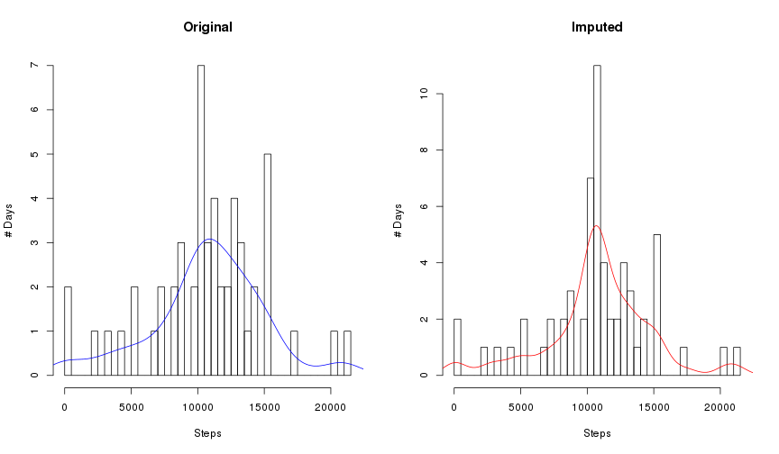

```r
#plot these next to each other.
par(mfrow=c(1,2))

plot(sum.hist, main='Original', xlab='Steps', ylab='# Days')
lines(sum.density, col='blue')

plot(imputed.sum.hist, main='Imputed', xlab='Steps', ylab='# Days')
lines(imputed.sum.density, col='red')
```

This side-by-side comparison makes it clear that the way we imputed the data has narrowed the variance in our original curve, skewing it towards it's original mean.

## Are there differences in activity patterns between weekdays and weekends?

To see what differences we have in the weekday activity versus the weekend activity, first we'll need to decide which observations came from weekdays, and which came from weekends.

```r
# We will be using str_pad from the stringr library to format the intervals
library(stringr)
# next we will process our imputed data, creating our column that shows us
# weekday versus weekend.
imputed.activity[,is.wday:={
    # turn '0' into '0000', and '345' into '0345' etc.
    t <- str_pad(interval, 4, pad='0')

    # format our newly padded interval into an ISO time stamp
    t <- paste(substr(t,0,2), substr(t,3,4), '00', sep=':')

    # turn our date and new time stamp into a POSIXlt object
    t <- strptime(paste(date, t, sep=' '), '%F %T', tz='GMT')

    # determine if it's a weekday or weekend
    if (t$wday != 0 & t$wday != 6) {
        'weekday'
    } else {
        'weekend'
    }
}, by=r]
```

```r
# transform our new column into a factor
imputed.activity[,is.wday:=as.factor(is.wday)]
```

[output not shown]

Now let's see what this data really looks like in a visual way:

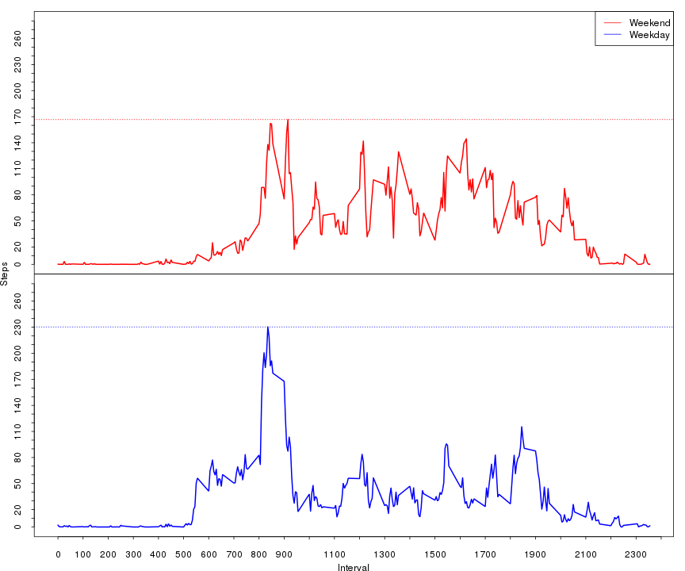

```r
# Set up our plotting parameters
par(mfrow=c(2,1), mar=c(0,0,0,0), oma=c(3,3,1,1), tcl='-.25')

# Weekend line
plot(imputed.activity[is.wday=='weekend',mean(steps), by=interval], type='l',
     axes=FALSE, col='red', lwd=2, ylim=c(0,280))
abline(h=max(imputed.activity[is.wday=='weekend',mean(steps), by=interval]$V1),
      lty=3, col="red")
# Draw a y-axis for this plot
axis(2, at=seq(0,280,10))
# Frame this plot
box()
# Add a legend for our whole plot
legend('topright', lwd=1, col=c('red', 'blue'),legend=c('Weekend', 'Weekday'))

#Weekday line
plot(imputed.activity[is.wday=='weekday',mean(steps), by=interval], type='l',
     axes=FALSE, col='blue', lwd=2, ylim=c(0,280))
abline(h=max(imputed.activity[is.wday=='weekday',mean(steps), by=interval]$V1),
      lty=3, col="blue")
# Add a y-axis
axis(2, at=seq(0,280,10))
# Add an x-axis for the whole plot
axis(1, at=seq(0,2455,100))
# frame the Weekday plot
box()

# Label our plot axes
mtext('Interval', side=1, outer=TRUE, line=2.2)
mtext('Steps', side=2, outer=TRUE, line=2.2)
```